# Per gene statistical comparison of CVs: permutation-based p-values

Joyce Hsiao

2015-11-12

**Last updated:** 2015-11-12

**Code version:** d9817bb5a076f7a795343d06bf4d268256aee7f8

## Objective

Quantify statistical significance of individual differences between adjusted CVs. Here we will focus on empirical p-values computed from permuted samples.

## Set up

```r
library("data.table")
library("dplyr")
library("limma")
library("edgeR")
library("ggplot2")
library("grid")
library("Humanzee")
theme_set(theme_bw(base_size = 12))
source("functions.R")
```

## Prepare data

Input quality single cells

```r
quality_single_cells <- read.table("../data/quality-single-cells.txt",
                                  stringsAsFactors = FALSE)
str(quality_single_cells)
```

```
'data.frame':   568 obs. of  1 variable:
 $ V1: chr  "NA19098.r1.A01" "NA19098.r1.A02" "NA19098.r1.A04" "NA19098.r1.A05" ...
```

Input annotation of only QC-filtered single cells. Remove NA19098.r2

```r
anno_filter <- read.table("../data/annotation-filter.txt",
                    header = TRUE,
                    stringsAsFactors = FALSE)
dim(anno_filter)
```

```
[1] 568   5
```

Import endogeneous gene molecule counts that are QC-filtered, CPM-normalized, ERCC-normalized, and also processed to remove unwanted variation from batch effet. ERCC genes are removed from this file.

```r
molecules_ENSG <- read.table("../data/molecules-final.txt",
                             header = TRUE, stringsAsFactors = FALSE)
stopifnot(NCOL(molecules_ENSG) == NROW(anno_filter))
```

## Import gene symbols

```r
gene_info <- read.table("../data/gene-info.txt", sep = "\t",
                        header = TRUE, stringsAsFactors = FALSE)
str(gene_info)
```

```
'data.frame':   6152 obs. of  5 variables:
 $ ensembl_gene_id   : chr  "ENSG00000000003" "ENSG00000000005" "ENSG00000000419" "ENSG00000000457" ...
 $ chromosome_name   : chr  "X" "X" "20" "1" ...
 $ external_gene_name: chr  "TSPAN6" "TNMD" "DPM1" "SCYL3" ...
 $ transcript_count  : int  3 2 7 5 10 4 12 2 13 8 ...
 $ description       : chr  "tetraspanin 6 [Source:HGNC Symbol;Acc:11858]" "tenomodulin [Source:HGNC Symbol;Acc:17757]" "dolichyl-phosphate mannosyltransferase polypeptide 1, catalytic subunit [Source:HGNC Symbol;Acc:3005]" "SCY1-like 3 (S. cerevisiae) [Source:HGNC Symbol;Acc:19285]" ...
```

## Compute normalized CV

We compute squared CV across cells for each individual and then for each individual CV profile, account for mean dependency by computing distance with respect to the data-wide coefficient variation on the log10 scale.

```r
ENSG_cv <- Humanzee::compute_cv(log2counts = molecules_ENSG,
                      grouping_vector = anno_filter$individual)

ENSG_cv_adj <- Humanzee::normalize_cv(group_cv = ENSG_cv,
                            log2counts = molecules_ENSG,
                            anno = anno_filter)
```

## Compute summary measure of deviation

- Standardize the each CV vectors

Individual CV vectors are standarized for individual CV mean and coefficients of variation across genes.

```r
df_cv <- data.frame(NA19098 = ENSG_cv_adj[[1]]$log10cv2_adj,
                    NA19101 = ENSG_cv_adj[[2]]$log10cv2_adj,
                    NA19239 = ENSG_cv_adj[[3]]$log10cv2_adj)

library(matrixStats)
df_norm <- sweep(df_cv, MARGIN = 2, STATS = colMeans(as.matrix(df_cv)), FUN = "-")
df_norm <- sweep(df_norm, MARGIN = 2, STATS = sqrt(colVars(as.matrix(df_cv))), FUN = "/")
colnames(df_norm) <- names(ENSG_cv_adj)
```

- SSM and SAM

Compute metrics for quantifying similarity between the three individual coefficients of variation.

```r
library(matrixStats)

df_norm <- as.data.frame(df_norm)
df_norm$squared_dev <- rowSums( ( df_norm - rowMedians(as.matrix(df_norm)) )^2 )
df_norm$abs_dev <- rowSums(abs( df_norm - rowMedians(as.matrix(df_norm)) ))
```

## Permtued p-vals

Confirm that the gene with the larger SSM and SAM are significant with a p-value of 0.

```r
load("rda/cv-adjusted-statistical-test-permute/permuted-pval.rda")
permuted_pval$squared_dev[which.max(df_norm$squared_dev)]
```

```
[1] 0
```

```r
permuted_pval$squared_dev[order(df_norm$squared_dev, decreasing = T)[3]]
```

```
[1] 0
```

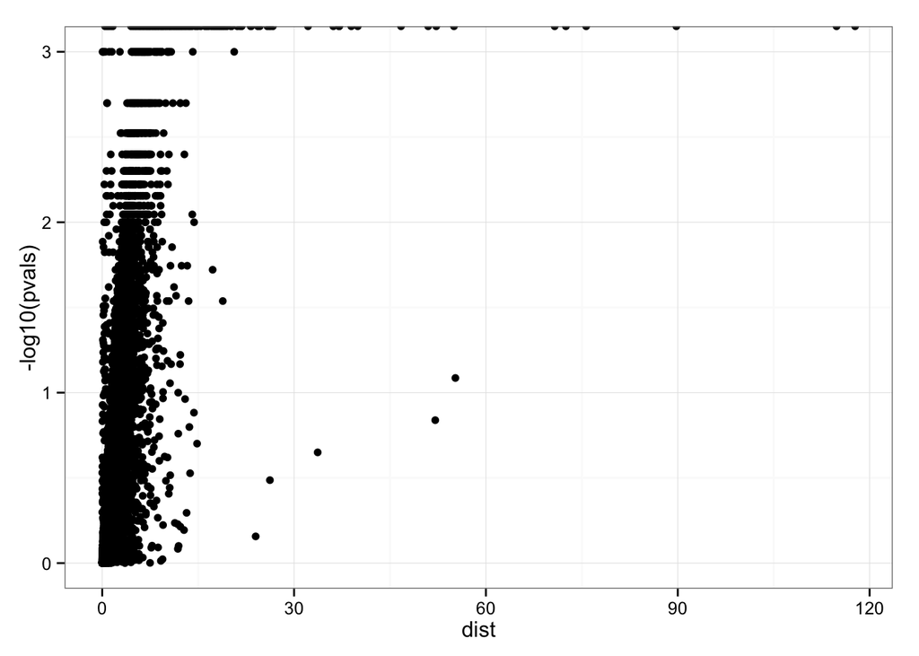

```r
library(ggplot2)
ggplot(data.frame(pvals = permuted_pval$squared_dev,
                  dist = df_norm$squared_dev),
       aes(x = dist, y = -log10(pvals))) +
  geom_point()
```

Gene with the largest Sum-of-Squared-Deviations.

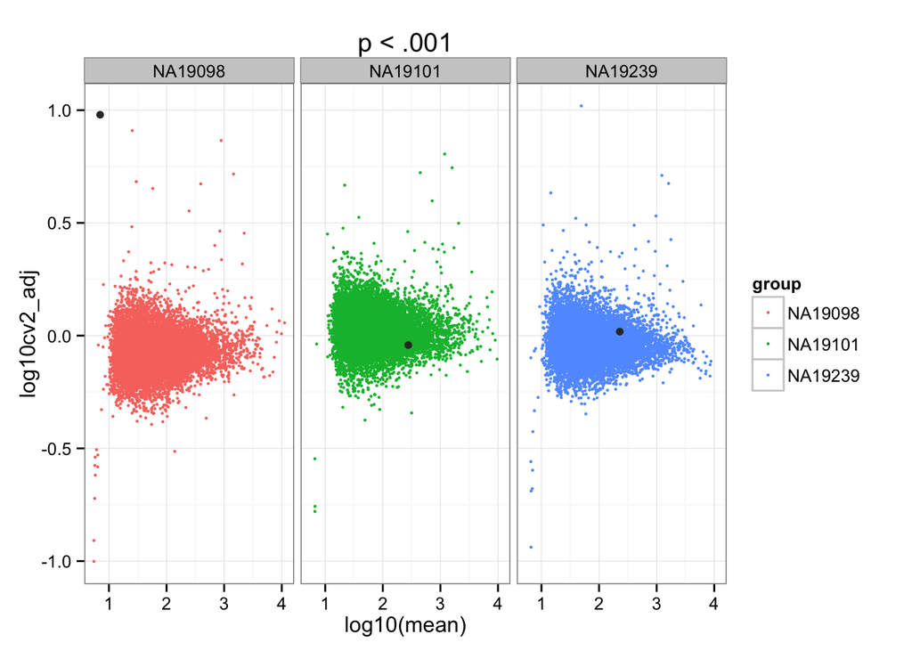

```r
ggplot(do.call(rbind, ENSG_cv_adj),
       aes(x = log10(mean), y = log10cv2_adj)) +
  geom_point(aes(col = group), cex = .8) + facet_wrap( ~ group) +
  ggtitle("p < .001") +
  geom_point(data = subset(do.call(rbind, ENSG_cv_adj),
                           c(1:NROW(ENSG_cv_adj[[1]])) %in%
                             order(df_norm$squared_dev, decreasing = TRUE )[1]),
             colour = "grey20")
```